# Neural Networks Assignment: Heart Disease Classification

It is very difficult to see any strong pairwise relationships or correlations between the features. The pairplot did not highlight any significant correlations. Next step is to create heatmaps to see this better.

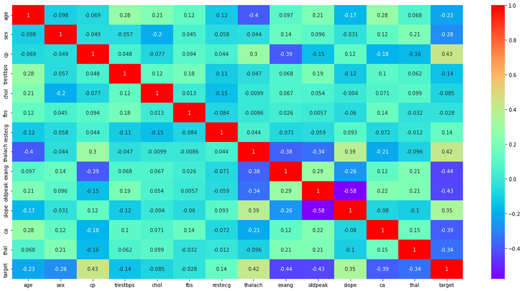

```python
plt.subplots(figsize=(20, 10))
sns.heatmap(rscaled_heart_df.corr(), annot=True, cmap="rainbow")
plt.show()
```

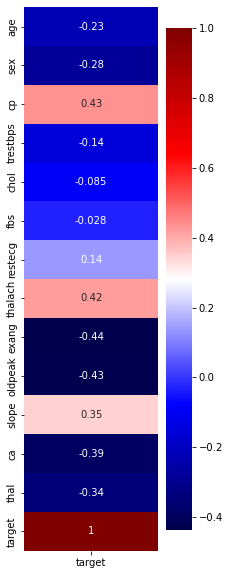

```python
# See if individual features correlate to target using vertical heatmap (heart disease: -1 = no, 0 = yes).

heart_corr = rscaled_heart_df.corr().loc[:,['target']]
plt.figure(figsize = (3,10))
sns.heatmap(heart_corr,annot = True, cmap='seismic')
```

Individual correlations to target summarised

- age = negative correlation (As age value goes up, heart disease value goes down. Increased age trends to no heart disease.)
- sex = negative correlation (as sex value goes up, heart disease value goes down. Male trends to no heart disease.)
- **cp = positive correlation (as cp value goes up, heart disease value goes up. Increased chest pain trends to heart disease.)**
- trestbps = slight negative correlation (as trestbps value goes up, heart disease value goes down. Increased resting blood pressure trends to no heart disease.)
- chol = slight negative correlation (as chol value goes up, heart disease value goes down. Increased cholesterol trends to no heart disease.)
- fbs = slight negative correlation (as fbs value goes up, heart disease value goes down. Increased fasting blood sugar trends to no heart disease.)
- **restecg = slight positive correlation (as restecg value goes up, heart disease value goes up. Increased resting ECG results value trends to heart disease.)**
- **thalach = positive correlation (as thalach value goes up, heart disease value goes up. Increased maximum heart rate trends to heart disease.)**
- exang = negative correlation (as exang value goes up, heart disease value goes down. Exercise angina (yes) trends to no heart disease.)
- oldpeak = negative correlation (as oldpeak value goes up, heart disease value goes down. Increased ST depression induced by exercise relative to rest trends to no heart disease.)
- **slope = positive correlation (as slope value goes up, heart disease value goes up. Downsloping slope trends to heart disease.)**
- ca = negative correlation (as ca value goes up, heart disease value goes down. Increased number of major vessels trends to no heart disease.)
- thal = negative correlation (as thal value goes up, heart disease value goes down. Reversable defect trends to no heart disease.)

## Split dataset for models

```python
# Define X and y for train test split
X = rscaled_heart_df.drop(columns=['target'], axis=1)
y = heart.target.values
X_train, X_test, y_train, y_test = train_test_split(X, y, test_size=0.2, random_state=56) # creates training and test sets
```

## Models (currently unfinished)

```
0.7868852459016393
```

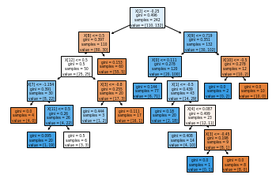

```python
# Make a decision tree
tree_mod = DecisionTreeClassifier(max_leaf_nodes=13)
tree_mod.fit(X_train, y_train)
# Make predictions
pred = tree_mod.predict(X_test)
# Show tree plot (clipped version for readability)
score1 = accuracy_score(y_test, pred)
# print(pred)
print(score1)
tree.plot_tree(tree_mod, filled=True)
plt.show()
```

See this [tutorial](https://elitedatascience.com/keras-tutorial-deep-learning-in-python) of a beginner's guide to deeep learning in python.

```python
from keras.models import Sequential
from keras.layers import Dense, Dropout, Activation, Flatten
from keras.layers import Convolution2D, MaxPooling2D
from keras.utils import np_utils
```

```python
classifier = Sequential()

# classifier.add(Dense(6, activation='relu', kernel_initializer='glorot_uniform',input_dim=11))

# Adding the input layer and the first hidden layer
classifier.add(Dense(11, kernel_initializer = 'uniform', activation = 'relu', input_dim = 13))

# Adding the second hidden layer
classifier.add(Dense(11, kernel_initializer = 'uniform', activation = 'relu'))

# Adding the output layer
classifier.add(Dense(1, kernel_initializer = 'uniform', activation = 'sigmoid'))

# Compiling the ANN
classifier.compile(optimizer = 'adam', loss = 'binary_crossentropy', metrics = ['accuracy'])
```

```python
classifier.fit(X_train, y_train, batch_size = 10, epochs = 100)
```

```
<keras.callbacks.History at 0x13f7a581a60>
```

```python
# Predicting the Test set results
y_pred = classifier.predict(X_test)
```

```
accuracy of the model:  0.8032786885245902
```

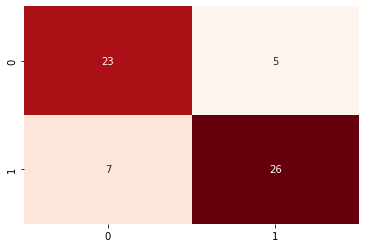

```python
cm1 = confusion_matrix(y_test, y_pred.round())
sns.heatmap(cm1,annot=True,cmap="Reds",fmt="d",cbar=False)
#accuracy score

ac1 = accuracy_score(y_test, y_pred.round())
print('accuracy of the model: ',ac1)
```

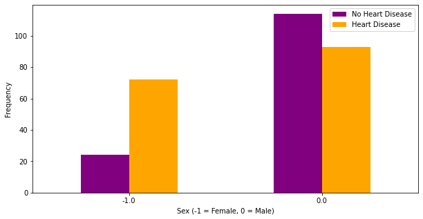

```python
pd.crosstab(rscaled_heart_df.sex, rscaled_heart_df.target).plot(kind="bar",figsize=(10,5),color=['purple','orange' ])
plt.xlabel('Sex (-1 = Female, 0 = Male)')
plt.xticks(rotation=0)
plt.legend(["No Heart Disease", "Heart Disease"])
plt.ylabel('Frequency')
plt.show()
```